# Lab3

Ali Haydar Ozgun

9/28/2021

Problem 1; Create five samples of 25 observations from a normal distribution with mean 200, and standard deviation 100. Compute the mean of each sample, and plot the means in a graph using ggplot2.

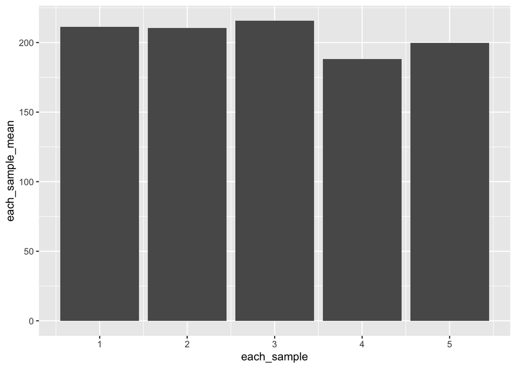

```r
# First we upload the necessary packages

library(ggplot2)
library(dplyr)
# Creating observations and sampling

outputs <- rnorm(5 * 25, mean = 200, sd = 100)

each_sample <- rep(1:5, each = 25)

my_data <- data.frame(each_sample, outputs)

# Calculating the mean of each sample

means_data <- my_data %>%
  group_by(each_sample) %>%
  summarize(each_sample_mean = mean(outputs))
# Plotting the mean

ggplot(means_data, aes(x = each_sample, y = each_sample_mean)) +
  geom_bar(stat = 'identity')
```

Helping Rate : 80

Problem 2; Additionally calculate the standard deviation of each sample from above. Use the standard deviations for error bars, and produce another graph with the means along with error bars using ggplot2.

```r
# Creating observations and sampling

outputs <- rnorm(5 * 25, mean = 200, sd = 100)

each_sample <- rep(1:5, each = 25)

my_data <- data.frame(each_sample, outputs)

# Calculating the standard deviation

means_data <- my_data %>%
  group_by(each_sample) %>%
  summarize(each_sample_mean = mean(outputs),
            each_sample_sd = sd(outputs))
```

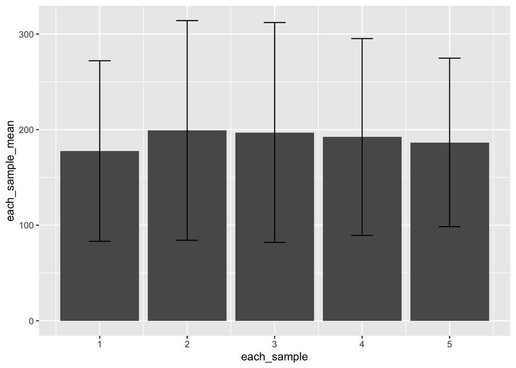

```r
# Plotting with error bar

ggplot(means_data, aes(x = each_sample, y = each_sample_mean)) +
  geom_bar(stat = 'identity') +
  geom_errorbar(aes(ymin = each_sample_mean - each_sample_sd,
                ymax = each_sample_mean + each_sample_sd), width = .25)
```

Helping Rate : 80

Problem 3; Demonstrate that the sample mean across a range of n, is an unbiased estimator of the population mean using a monte-carlo simulation.

1. The population is a normal distribution with mean = 10, standard deviation = 5.
2. Test a variety of n (sample size), including n = 2, 5, 10, 50, and 100
3. For each sample size n, your task is to draw 10,000 samples of that size, then for each sample, calculate the sample mean. If the mean is unbiased, then we expect that “on average” the sample means will be the same as the population mean. To determine if this is true, compute the mean of the sample means that you produce to see if it is close to the population mean.
4. Show the mean of the sample means for each sample size.

```r
# Part a; The population is a normal distribution with mean = 10, standard deviation = 5
rnorm(2, mean = 10, sd = 5)
```

```
## [1] 10.428182  9.948326
```

```r
# Part b; Test a variety of n (sample size), including n = 2, 5, 10, 50, and 100

rnorm(2, mean = 10, sd = 5) # for n = 2
```

```
## [1] 20.353263  6.027847
```

```r
rnorm(5, mean = 10, sd = 5) # for n = 5
```

```
## [1] 10.404019 12.811589 10.153932  5.963881 15.995265
```

```r
rnorm(10, mean = 10, sd = 5) # for n = 10
```

```
##  [1] 19.240128 14.463004  1.485473 11.700895 10.616663 15.923609  5.315498
##  [8] 13.917931  5.635862 15.715685
```

```r
rnorm(50, mean = 10, sd = 5) # for n = 50
```

```
##  [1] 13.73578272  8.25648442 15.52434858 12.34822312  5.21214207 11.97819120
##  [7]  0.03840587 25.57582067  0.04147225 14.17411768 13.65258362  5.93790732
## [13]  7.82521924  9.48979422  4.01653959  4.48683529  8.51065763 14.97869241
## [19]  7.02547755  9.83328564  8.64142909  3.02044356  7.10627649  9.13867843
## [25] 15.69919866 14.12477991 12.94323654 16.08953893  0.24144981  7.01730654
## [31] 12.20135477  6.22561818 10.05707524  9.76240422  2.69157955  6.11916129
## [37] 14.95021592 -0.05740583 11.71768120  1.27526550 20.19375529  6.04290924
## [43]  8.89789907 11.69112319  9.80994744 12.00516022  7.95527911  7.99116824
## [49] 14.70149313  3.91062365
```

```r
rnorm(100, mean = 10, sd = 5) #for n = 100
```

```
##   [1] 17.3417337 11.8320752 12.6340791 15.6519634 19.1856071  7.2885224
##   [7]  9.3323085 11.4422355  6.3715898  5.8230807 14.3400538 22.3132978
##  [13] 21.0541044  2.5922500 14.9028999  1.4966242 11.3556434  6.5114642
##  [19] 10.3096363  9.8177124  0.5480038 16.5818829  4.6205130 13.1559166
##  [25]  7.5038038 16.8397474  6.7809561  7.5398348  7.5804146  8.6709484
##  [31] 13.6182693  5.3029141 15.9374582  3.3532348 18.8730955  8.3020487
##  [37]  9.7234015 18.8505701  0.2908752  8.6606619  4.8713759 14.4723695
##  [43] 16.9912253 10.8727588  9.2168259  9.0388039  7.3375777  5.4536348
##  [49]  1.6083497 16.4667055 10.2301023  4.8797707 16.3089828  5.7255682
##  [55]  6.6044220  1.5024957  3.4483666 14.8203456 12.2718103  5.9503693
##  [61]  8.0055109 14.0547938 27.1080549 11.8480074 13.4799305  8.9665252
##  [67]  6.6093781 11.3256604 11.9920941 -2.0141525 11.0678009 15.3115578
##  [73] 19.5636604  9.2101064  8.9241741 16.5905545 11.0090330  4.1824986
##  [79]  4.7968112  6.4228478 12.6207555  4.8466425  1.4833805  9.9260639
##  [85] 12.0870711  9.7625047 13.0255792 13.1554381  5.6783508  2.2208600
##  [91]  4.9123959  2.9939299 10.1607893 19.3510950  5.5687542 16.3981105
##  [97]  7.8272765 10.5774239 12.1060961 17.7030756
```

```r
# Part c; For each sample size n, your task is to draw 10,000 samples of that size, then for each sample, calculate the sample mean. If the mean is unbiased, then we expect that “on average” the sample means will be the same as the population mean. To determine if this is true, compute the mean of the sample means that you produce to see if it is close to the population mean.

# sample size 2

size_n <- rnorm(2 * 10000, mean = 10, sd = 5)

sample_for_n <- rep(1:10000, each = 2)

new_data <- data.frame(sample_for_n, size_n)

data_summarize <- new_data %>%
  group_by(sample_for_n) %>%
  summarize(sample_for_n_mean = mean(size_n))
mean(data_summarize$sample_for_n_mean) # mean of the sample means for each sample size
```

```
## [1] 9.969117
```

```r
# Sample size 5

size_n <- rnorm(5 * 10000, mean = 10, sd = 5)

sample_for_n <- rep(1:10000, each =5)

new_data <- data.frame(sample_for_n, size_n)

data_summarize <- new_data %>%
  group_by(sample_for_n) %>%
  summarize(sample_for_n_mean = mean(size_n))
mean(data_summarize$sample_for_n_mean)
```

```
## [1] 10.03095
```

```r
# Sample size 10

size_n <- rnorm(10 * 10000, mean = 10, sd = 5)

sample_for_n <- rep(1:10000, each = 10)

new_data <- data.frame(sample_for_n, size_n)

data_summarize <- new_data %>%
  group_by(sample_for_n) %>%
  summarize(sample_for_n_mean = mean(size_n))
mean(data_summarize$sample_for_n_mean)
```

```
## [1] 9.953291
```

```r
# Sample size 50

size_n <- rnorm(50 * 10000, mean = 10, sd = 5)

sample_for_n <- rep(1:10000, each = 50)

new_data <- data.frame(sample_for_n, size_n)

data_summarize <- new_data %>%
  group_by(sample_for_n) %>%
  summarize(sample_for_n_mean = mean(size_n))
mean(data_summarize$sample_for_n_mean)
```

```
## [1] 10.00501
```

```r
# Sample size 100

size_n <- rnorm(100 * 10000, mean = 10, sd = 5)

sample_for_n <- rep(1:10000, each = 100)

new_data <- data.frame(sample_for_n, size_n)

data_summarize <- new_data %>%
  group_by(sample_for_n) %>%
  summarize(sample_for_n_mean = mean(size_n))
mean(data_summarize$sample_for_n_mean)
```

```
## [1] 9.998971
```

```r
### Above calculations also can be written in a loop ;

n_size <- c(2, 5, 10, 50, 100)
for (n in n_size) {
  size_n <- rnorm(n * 10000, mean = 10, sd = 5)

  sample_for_n <- rep(1:10000, each = n)

  new_data <- data.frame(sample_for_n, size_n)

  data_summarize <- new_data %>%
    group_by(sample_for_n) %>%
    summarize(sample_for_n_mean = mean(size_n))

  print(mean(data_summarize$sample_for_n_mean))

}
```

```
## [1] 9.966326
```

```
## [1] 9.991013
```

```
## [1] 10.0103
```

```
## [1] 9.999837
```

```
## [1] 9.996301
```

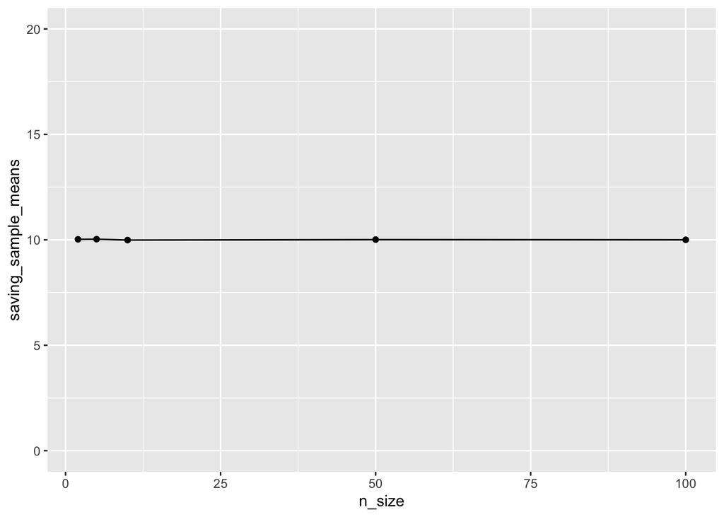

```r
### Saving the values and Plotting;

n_size <- c(2, 5, 10, 50, 100)
saving_sample_means <- c()
for (n in 1 : length(n_size)) {
  size_n <- rnorm(n_size[n] * 10000, mean = 10, sd = 5)

  sample_for_n <- rep(1:10000, each = n_size[n])

  new_data <- data.frame(sample_for_n, size_n)

  data_summarize <- new_data %>%
    group_by(sample_for_n) %>%
    summarize(sample_for_n_mean = mean(size_n))

  saving_sample_means[n] <- mean(data_summarize$sample_for_n_mean)

}
saved_data <- data.frame(n_size, saving_sample_means)

ggplot(saved_data, aes(x = n_size, y = saving_sample_means, group = 1))+
         geom_point() +
         geom_line() +
          coord_cartesian(ylim = c(0, 20))
```

Helping Rate : 60

Problem 4; Use a monte carlo simulation to compare the standard deviation formulas (divide by N vs N-1), and show that the N-1 formula is a better unbiased estimate of the population standard deviation, especially for small n.

1. Use the same normal distribution and samples sizes from above
2. Rather than computing the mean for each sample, compute both forms of the standard deviation formula, including the sample standard deviation that divides by N-1, and the regular standard deviation that divides by N

c)You should have 10,000 samples for each sample size, and 10,000 standard deviations for each the sample and regular standard deviation. Your task is to find the average of each, for each sample-size.

d)Which of the standard deviations is more systematically biased? That is, which one is systematically worse at estimating the population standard deviation?

```r
# We need to write a SD function. Because the ''sd()'' function uses ''n-1'' in R

N_sd_function <- function(x){
  sum((mean(x) - x) ^ 2) / length(x)
}


n_size <- c(2, 5, 10, 50, 100)
saving_sample_sd <- c()
saving_sample_sd_N <- c()
for (n in 1 : length(n_size)) {
  size_n <- rnorm(n_size[n] * 10000, mean = 10, sd = 5)

  sample_for_n <- rep(1:10000, each = n_size[n])

  new_data <- data.frame(sample_for_n, size_n)

  data_summarize <- new_data %>%
    group_by(sample_for_n) %>%
    summarize(sample_for_n_sd = sd(size_n),
              sample_for_n_sd_N = N_sd_function(size_n))

  saving_sample_sd[n] <- mean(data_summarize$sample_for_n_sd)
  saving_sample_sd_N[n] <- mean(data_summarize$sample_for_n_sd_N)

}
```

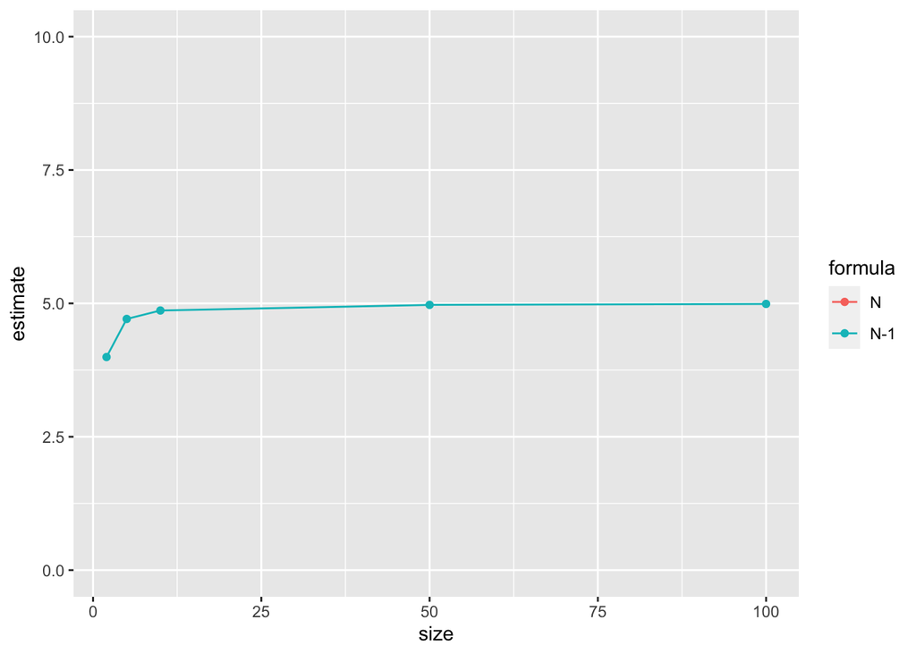

```r
saved_data <- data.frame(size = rep(n_size, 2),
                         estimate = c(saving_sample_sd_N, saving_sample_sd),
                         formula = c(rep('N', 5), rep('N-1', 5)))

ggplot(saved_data, aes(x = size, y = estimate, group = formula, color = formula))+
         geom_point() +
         geom_line() +
          coord_cartesian(ylim = c(0, 10))
```

Helping Rate : 40